# Reproducible logistic regression models

Steph Locke (@SteffLocke)

2017-04-07

# 1 Logistic regression

We uses a logistic regression to be able to use our simple linear regression methods against categorical data.

## 1.1 Linear Regression

In a linear regression, the data we are trying to predict might look like:

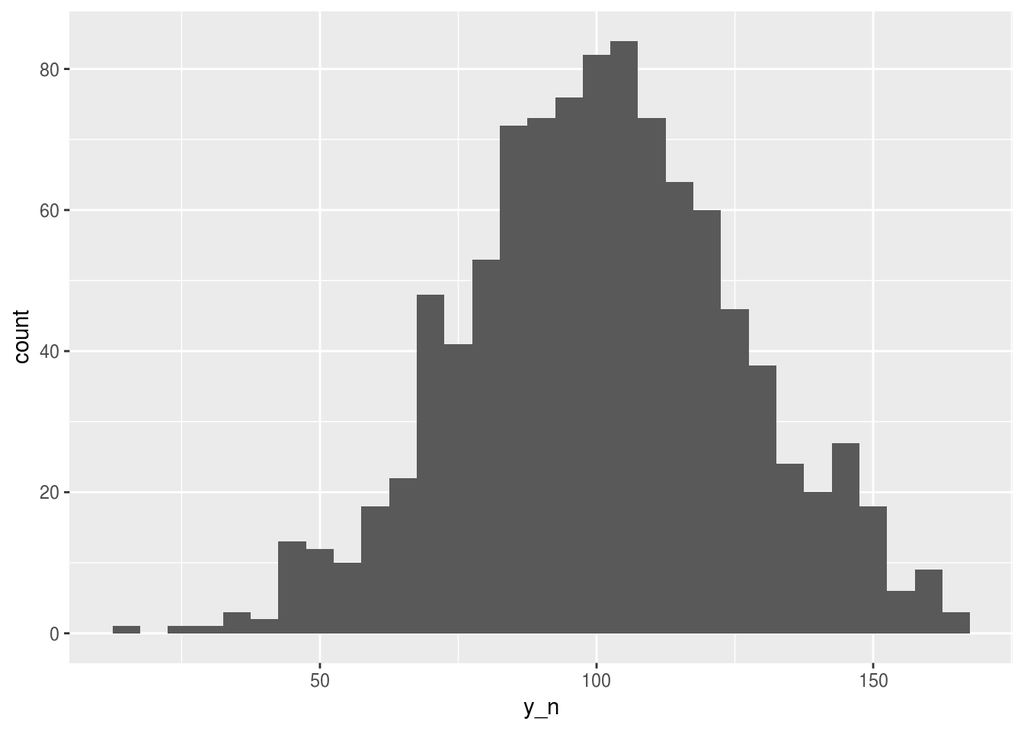

## 1.2 Binomial class

In a logistic regression, the data looks like:

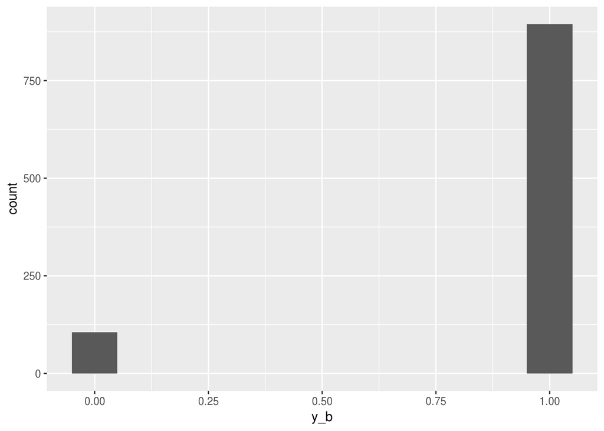

## 1.3 Probability

Trying to plot a standard regression would result in lots of error, instead we need to do something to make the results of a linear regression to put values closer to the two binomial outcomes.

We could use the probability of a given outcome as this gives us a range of values.

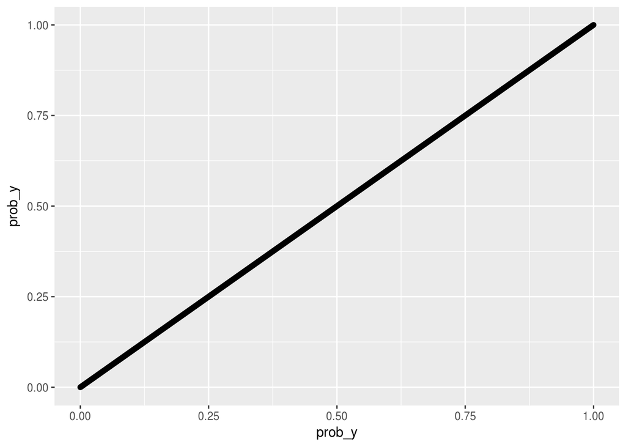

```r
prob_y<-seq(0,1, by=.001)
qplot(prob_y,prob_y)
```

The trouble with probabilities is they must be within 0 and 1 to make any sense and it would be tough to bind a linear regression to this range.

## 1.4 Odds

To bust out of this range, we could use odds, the probability of something happening versus it not happening to create a more dispersed value.

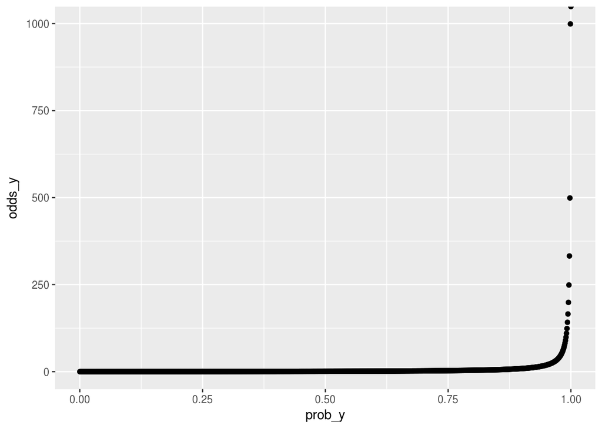

```r
odds_y<- prob_y/(1-prob_y)
qplot(prob_y,odds_y)
```

Using odds allows us to exceed 1, but there’s still no negative values allowed. Additionally, the relationship is distribution of values is difficult to model linearly.

## 1.5 Logit

To be able to get both a positive and a negative range of values allowed, we can take the log of the odds.

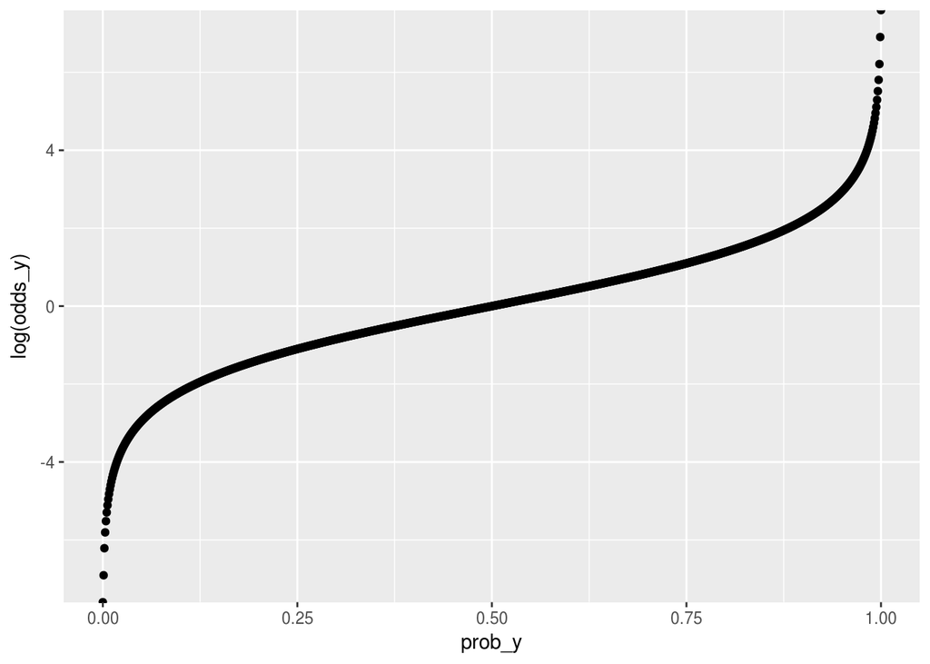

```r
qplot(prob_y, log(odds_y))
```

This now gives us a strong dispersal of values into positive and negative ranges, with a distribution much more suited to a linear regression model.

We can take a nuanced probabilistic approach to values, or simply say if the logit is positive, we predict the outcome 1, if not the outcome 0.

## 1.6 Transforming logits

To get back to a probability from a logit (or vice versa) is pretty simple but I wrote some helper functions in the package optiRum to facilitate this.

```r
library(optiRum)

logits     <- -4:4
odds       <- logit.odd(logits)
probs      <- odd.prob(odds)
pred_class <- logits>=0

knitr::kable(data.frame(logits,odds,probs,pred_class))
```

| logits | odds | probs | pred_class |
| --- | --- | --- | --- |
| -4 | 0.0183156 | 0.0179862 | FALSE |
| -3 | 0.0497871 | 0.0474259 | FALSE |
| -2 | 0.1353353 | 0.1192029 | FALSE |
| -1 | 0.3678794 | 0.2689414 | FALSE |
| 0 | 1.0000000 | 0.5000000 | TRUE |
| 1 | 2.7182818 | 0.7310586 | TRUE |
| 2 | 7.3890561 | 0.8807971 | TRUE |
| 3 | 20.0855369 | 0.9525741 | TRUE |
| 4 | 54.5981500 | 0.9820138 | TRUE |

```r
prob.odd
```

```
## function (prob)
## {
##     prob/(1 - prob)
## }
## <environment: namespace:optiRum>
```

```r
odd.logit
```

```
## function (odds)
## {
##     log(odds)
## }
## <environment: namespace:optiRum>
```

```r
logit.odd
```

```
## function (logit)
## {
##     exp(logit)
## }
## <environment: namespace:optiRum>
```

```r
odd.prob
```

```
## function (odds)
## {
##     odds/(1 + odds)
## }
## <environment: namespace:optiRum>
```

# 2 Analysis workflow

- Understand the problem
- Gather some data
- Clean the data
- Clean the data some more
- Exploration and visualisation
- Feature Reduction
- Feature Engineering
- (Depending on models) Feature Selection
- Candidate models builds
- Evaluate models
- In-depth evaluation of selected model
- Productionising

# 3 Sources of change in analysis

## 3.1 Exercise

What sort of things can alter the results of a piece of analysis?

## 3.2 Answers

- Changes in data
- Changes in code behaviours
- Changes in behaviours in dependencies
- Randomness

# 4 Accounting for change

## 4.1 Exercise

What sort of things can we do to prevent changes creeping into our analysis that stop it from being “deterministic”?

## 4.2 Answers

- Checksums to flag if anything has changed
- Keeping a seperate copy of data
- Keeping dependencies the same over time
- Source control
- Unit testing and validating code
- `set.seed`

# 5 GLM step-by-step – Project setup

## 5.1 Project checklist

- Git
- Project options
  - No Rdata or history!
  - Insert spaces for tabs
- Packrat +`packrat::init()`
- Folder structure
  - data
  - processeddata
  - analysis
  - outputs
  - docs
- DESCRIPTION
- LICENSE
- .Rbuildignore
- README.Rmd
- Makefile
  - [Karl Broman on Makefiles](http://kbroman.org/minimal_make/)
- .travis.yml

## 5.2 Travis setup

- [Travis CI](https://travis-ci.org)
- [Travis ref](https://docs.travis-ci.com/user/languages/r/)

## 5.3 Github setup

# 6 GLM step-by-step – Data

- Source
- Verification steps
- Multiple outputs?
- Main report
- Supplementary data quality report
- Shiny?

# 7 GLM step-by-step – Data processing

- Cleaning steps
- Sampling
- Feature scaling
- Univariate analysis
- Bivariate analysis

# 8 GLM step-by-step – Candidate models

- Feature selection
- Various glm* models

# 9 GLM step-by-step – Evaluation

- Scaling sample
- Single model evaluation techniques
- Comparing multiple models
- Cross-validation

# 10 GLM step-by-step – Model selection

- Using evaluation metrics to select best model
- Presenting model
- In-depth evaluation of best model

# 11 GLM step-by-step – Supplementary materials

- Data lineage
- Data quality
- Feature analysis in-depth
- Candidate model evaluations
- Code
- Reproducibility info